# EJERCICIO DE EVALUACIÓN, ANÁLISIS Y PREDICCIÓN DE SERIES TEMPORALES

PRECIPITACIONES POR MES (MM) EN ZARAGOZA.

Jonás Jiménez Gil (Universidad Complutense de Madrid)  
2022-10-13

# Introducción: Presentación de la serie a analizar

```r
library(readxl)
library(ggplot2)
library(ggfortify)
library(zoo)
library(forecast)
library(tseries)
```

# Representación gráfica y descomposición estacional

## Representación gráfica

```r
# Leemos el excel donde tenemos nuestra tabla de precipitaciones/mes
Precipitaciones_df <- read_xlsx(path = "./PrecipitacionesMesZaragoza.xlsx")
```

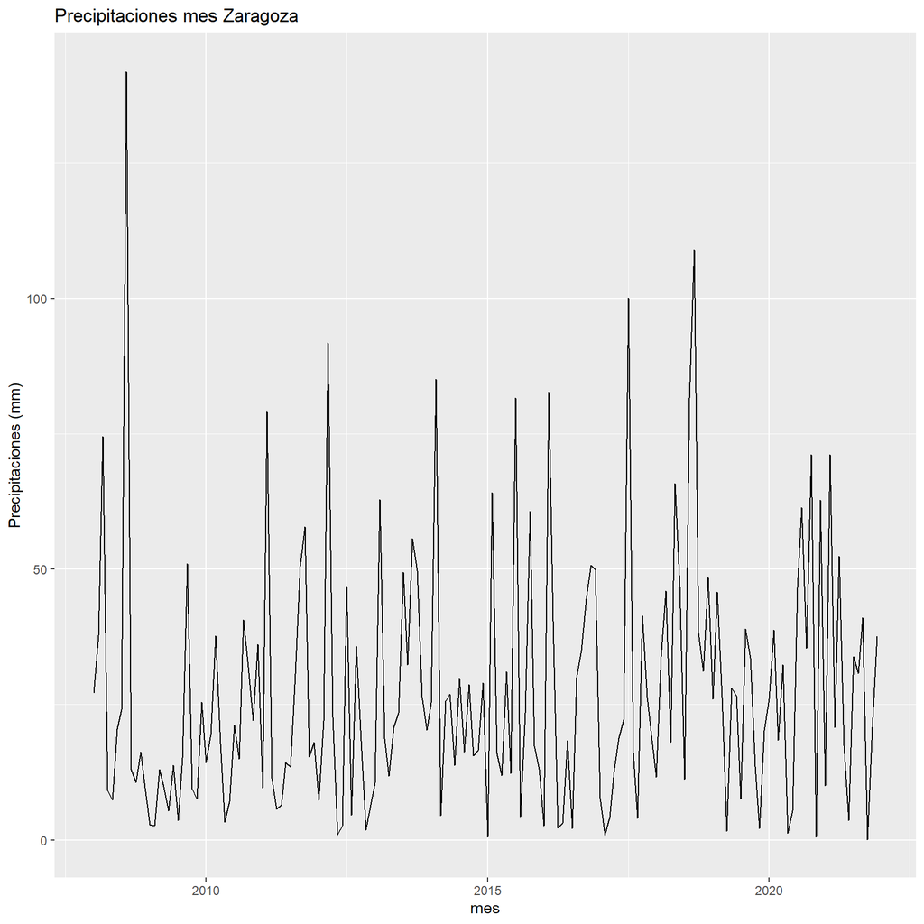

```r
Precipitaciones <- ts(Precipitaciones_df[,-1], start = c(2008,1), frequency = 12)
autoplot(Precipitaciones, ts.colour = 'blue') + ggtitle("Precipitaciones mes Zaragoza") + xlab ("mes") + ylab("Precipitaciones (mm)")
```

- **¿La serie es estacionaria?** Si, porque tiene media más o menos constante.
- **¿Tiene tendencia?** No se observa una tendencia evidente en la gráfica
- **¿Tiene comportamiento estacional?** Si
- **¿Cuál es el periodo?** 12

## Descomposición estacional

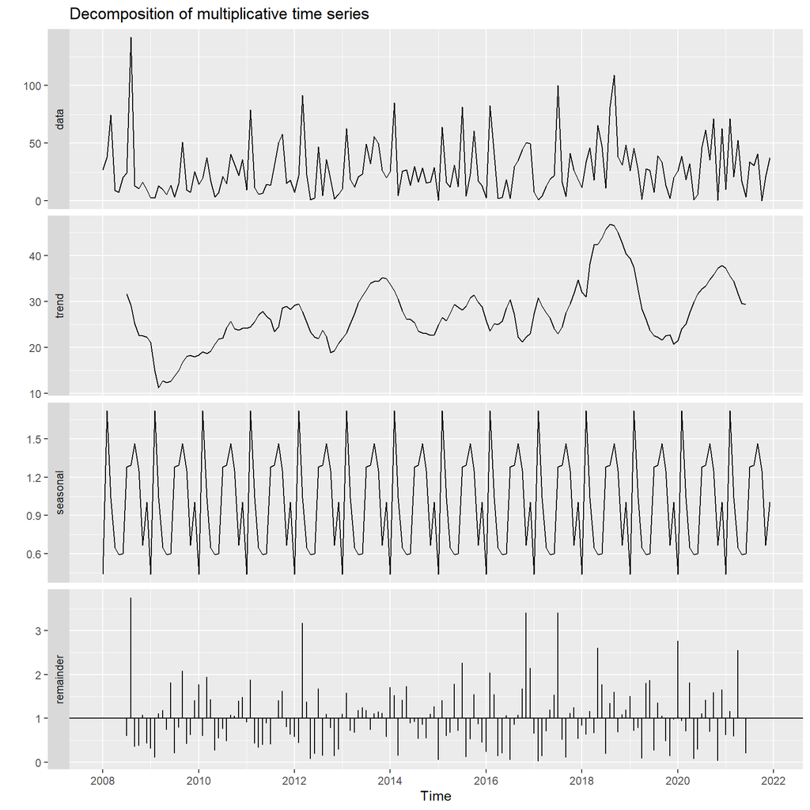

```r
#Realizamos la descomposición estacional según el método multiplicativo
Precipitaciones_Comp <- decompose(Precipitaciones, type = c("multiplicative"))
#Lo representamos gráficamente
autoplot(Precipitaciones_Comp, ts.colour = "blue")
```

Podemos visualizar que del 2009 al 2021 hay una tendencia creciente en el total de precipitaciones.

```r
#Mostramos los coeficientes de estacionalidad en una tabla
knitr::kable(Precipitaciones_Comp$figure, digits =2,caption = "Coef Estacionalidad")
```

Table 1: Coef Estacionalidad

| x |
| --- |
| 0.44 |
| 1.72 |
| 1.04 |
| 0.65 |
| 0.59 |
| 0.60 |
| 1.28 |
| 1.30 |
| 1.46 |
| 1.25 |
| 0.67 |
| 1.00 |

Observamos por ejemplo como febrero y septiembre tienen un 72 y 46% más precipitaciones que la media, mientras que enero es el més más seco con únicamente el 44% respecto a la media. Resulta sorprendente que los meses de julio y agosto son considerablemente más lluviosos que noviembre y diciembre

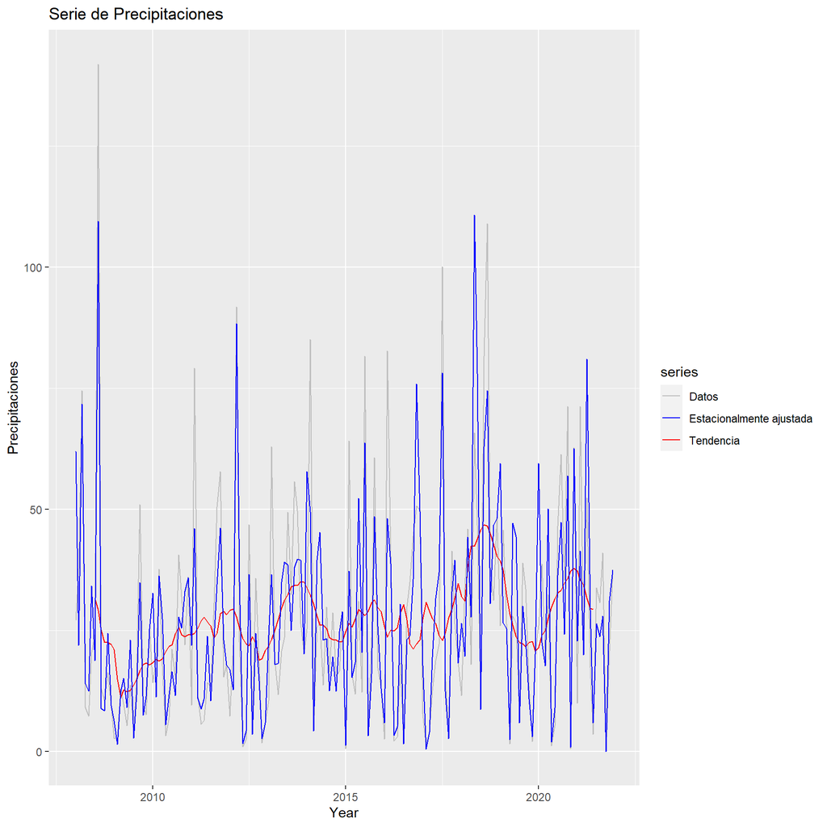

```r
#Calculamos la gráfica con los datos estacionalmente ajustados y la tendencia
autoplot(Precipitaciones, series="Datos") +
autolayer(trendcycle(Precipitaciones_Comp), series="Tendencia")+
autolayer(seasadj(Precipitaciones_Comp), series="Estacionalmente ajustada")+
xlab("Year") + ylab("Precipitaciones") +
ggtitle("Serie de Precipitaciones") +
scale_colour_manual(values=c("gray","blue","red"),
                    breaks=c("Datos","Estacionalmente ajustada","Tendencia"))
```

Confirmamos que la tendencia es creciente desde alrededor el año 2009 al 2021

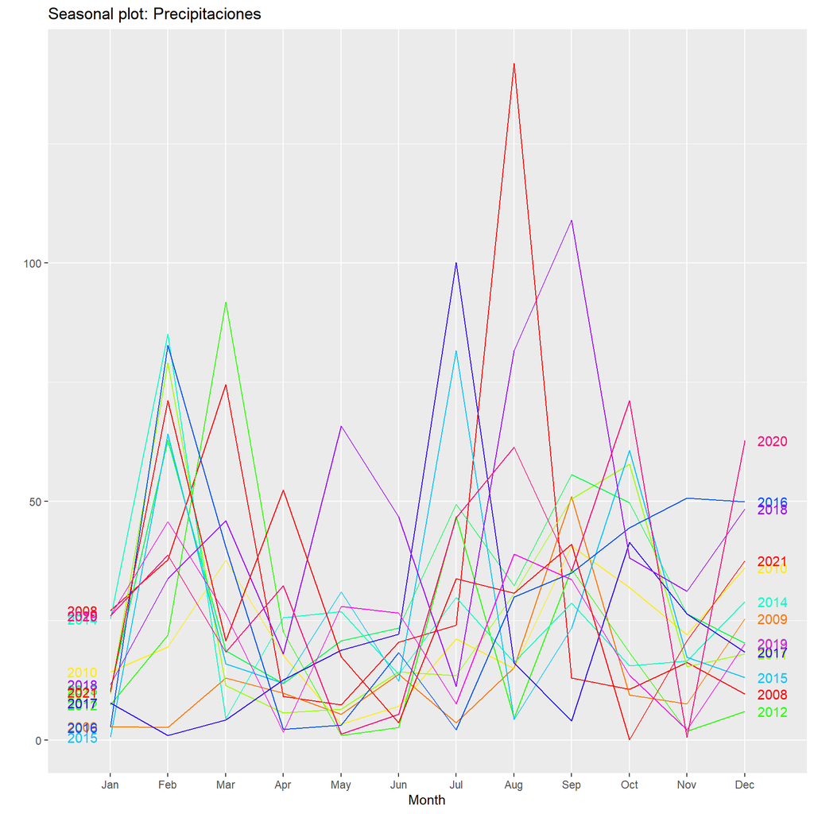

```r
#También podemos representar gráficamente los valores separados por años
ggseasonplot(Precipitaciones, year.labels = TRUE, year.labels.left = TRUE, col=rainbow(13))
```

# Búsqueda de modelo de suavizado exponencial más adecuado

```r
#Creamos un modelo train con todos los datos hasta el último año y un modelo test con solamente los datos del último año
Precipitaciones_train <- window(Precipitaciones, end=c(2021,1))
Precipitaciones_test <- window(Precipitaciones, start=c(2021,1))
```

Primero vamos a probar con los métodos de Holt, eliminaremos el método de alisado simple ya que la serie tiene una tendencia creciente y este método solamente nos sirve cuando la serie no tiene tendencia ni creciente ni decreciente

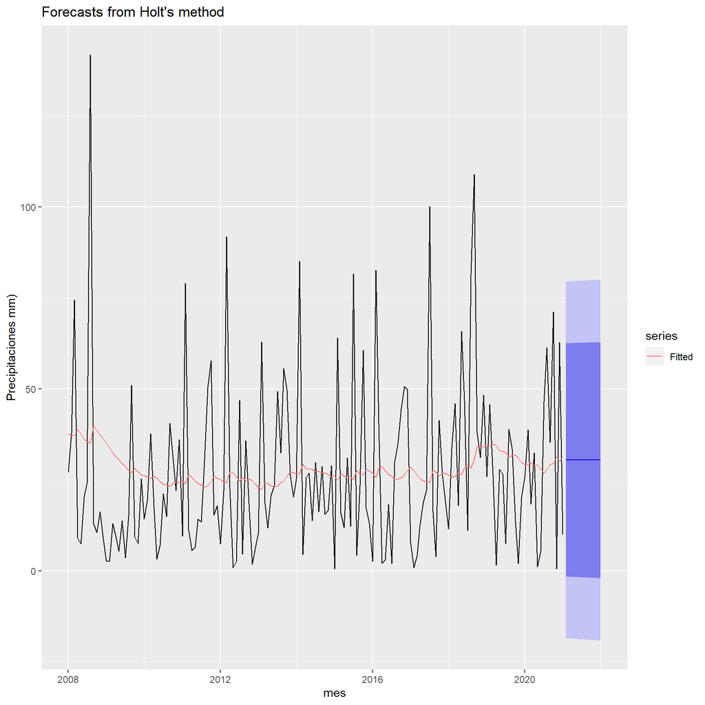

```r
#Representamos la serie original y la suavizada con las predicciones con el método de Holt
Predicciones_sh <- holt(Precipitaciones_train, h=12)
autoplot(Predicciones_sh) + autolayer(fitted(Predicciones_sh), series="Fitted") +ylab("Precipitaciones mm)") +
xlab("mes")
```

```r
knitr::kable(Predicciones_sh$model$par, digits = 4, caption = "Parámetros Holt")
```

Table 2: Parámetros Holt

|  | x |
| --- | --- |
| alpha | 0.0443 |
| beta | 0.0001 |
| l | 37.6998 |
| b | 0.0073 |

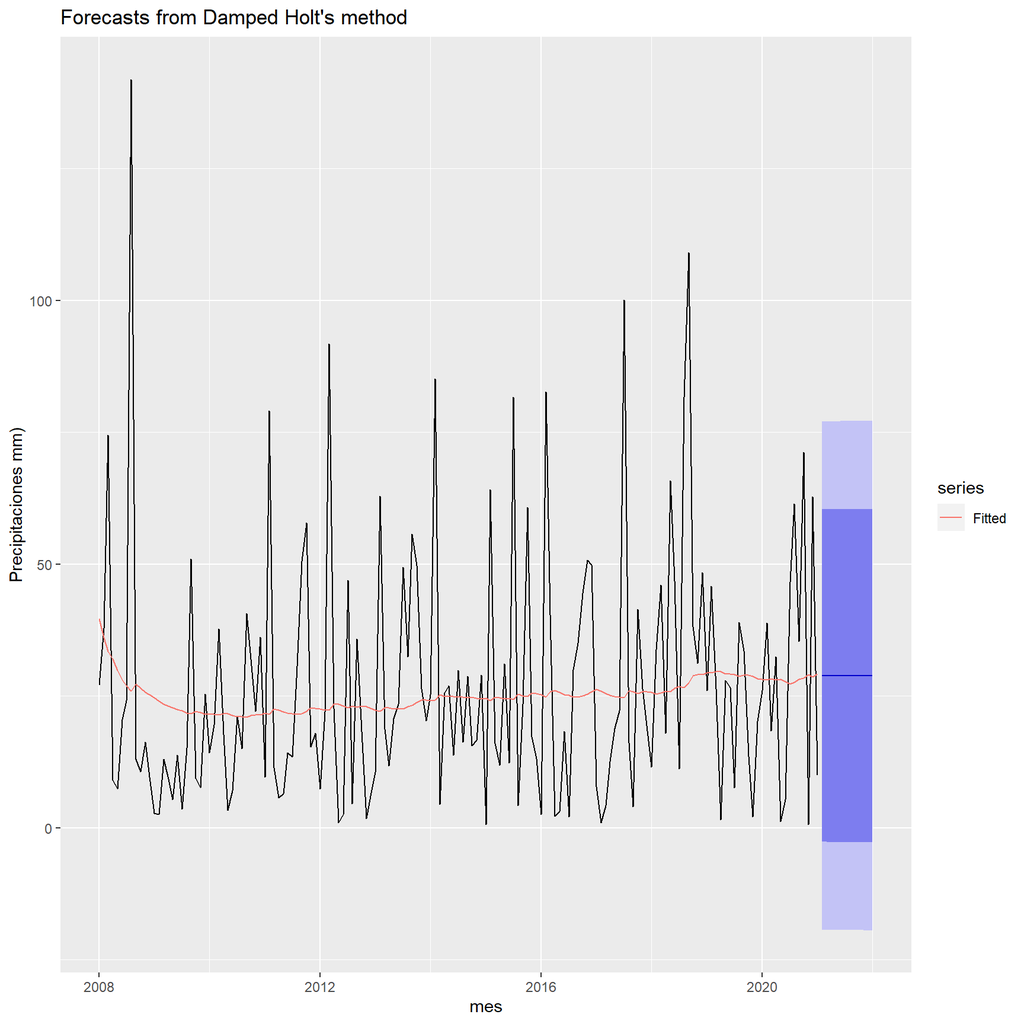

```r
#Representamos la serie original y la suavizada con las predicciones con el método de Holt amortiguado (Damped)
Predicciones_shd <- holt(Precipitaciones_train, damped = TRUE, h=12)
autoplot(Predicciones_shd) +autolayer(fitted(Predicciones_shd), series="Fitted") +
ylab("Precipitaciones mm)") + xlab("mes")
```

```r
knitr::kable(Predicciones_sh$model$par, digits = 4, caption = "Parámetros Damped Holt")
```

|  | x |
| --- | --- |
| alpha | 0.0443 |
| beta | 0.0001 |
| l | 37.6998 |
| b | 0.0073 |

Ahora vamos a realizar el método de suavizado para series con estacionalidad: el método Holt-Winters.

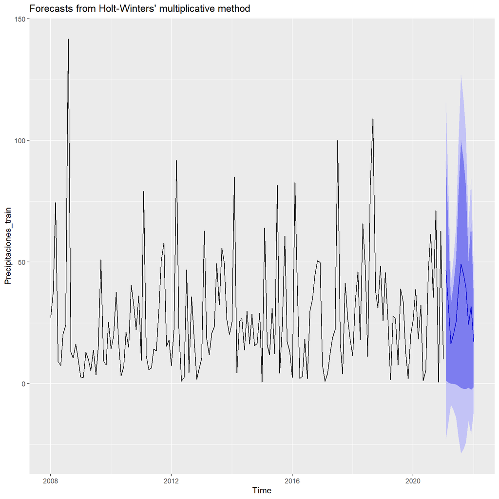

```r
#Calculamos las predicciones utilizando el método Holt-Winters para los próximos 12 meses
Predicciones_shw <- hw(Precipitaciones_train, h=12, seasonal="multiplicative",
                      level = c(80,95))
#Representamos la predición en una gráfica
autoplot(Predicciones_shw)
```

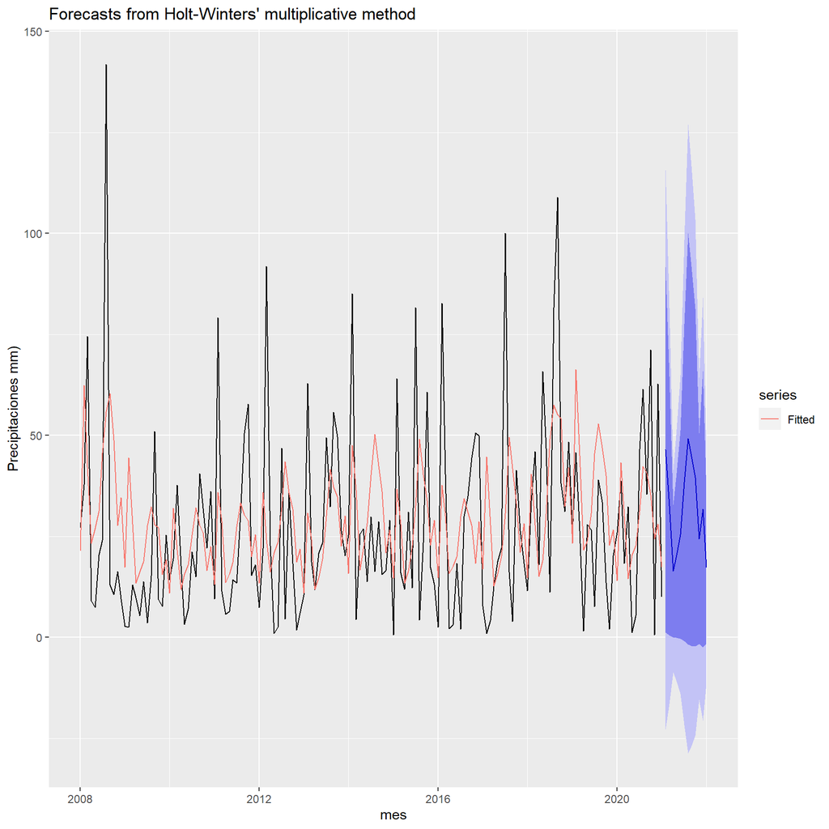

```r
#Representamos la serie original y la suavizada con las predicciones con el método de Holt-Winters
autoplot(Predicciones_shw)+autolayer(fitted(Predicciones_shw), series="Fitted") +
ylab("Precipitaciones mm)") + xlab("mes")
```

```r
#Visualizamos las prediciones mostrándolas en una tabla
print(Predicciones_shw)
```

```
         Point Forecast       Lo 80     Hi 80      Lo 95     Hi 95
Feb 2021       46.51545  1.24661870  91.78429 -22.717255 115.74816
Mar 2021       32.62208  0.54719812  64.69697 -16.432221  81.67639
Apr 2021       16.49045  0.10984624  32.87106  -8.561522  41.54242
May 2021       20.31020 -0.07184943  40.69225 -10.861456  51.48186
Jun 2021       25.43214 -0.35153134  51.21581 -14.000581  64.86486
Jul 2021       38.35462 -0.92790392  77.63713 -21.722814  98.43204
Aug 2021       49.17816 -1.70395957 100.06029 -28.639329 126.99566
Sep 2021       44.88110 -2.02817630  91.79037 -26.860447 116.62264
Oct 2021       39.57751 -2.20907658  81.36409 -24.329558 103.48457
Nov 2021       24.45757 -1.62711315  50.54225 -15.435509  64.35065
Dec 2021       31.77917 -2.45730838  66.01565 -20.581007  84.13935
Jan 2022       17.26159 -1.52257309  36.04576 -11.466309  45.98949
```

```r
#Visualizamos los parámetros del modelo ajustado
knitr::kable(Predicciones_shw$model$par, format = "pipe", digits = 4, caption = "Estimadores de los parámetros Holt-Winters")
```

Table 3: Estimadores de los parámetros Holt-Winters

|  | x |
| --- | --- |
| alpha | 0.1140 |
| beta | 0.0010 |
| gamma | 0.0001 |
| l | 40.2654 |
| b | 0.4889 |
| s0 | 0.9705 |
| s1 | 0.7495 |
| s2 | 1.2166 |
| s3 | 1.3842 |
| s4 | 1.5223 |
| s5 | 1.1909 |
| s6 | 0.7926 |
| s7 | 0.6350 |
| s8 | 0.5173 |
| s9 | 1.0267 |
| s10 | 1.4689 |

Se considera que este método (Holt-Winters) es el más adecuado para nuestra serie, tanto porque se adapta para series con estacionalidad como por sus resultados.

# Representar la serie y sus resultados

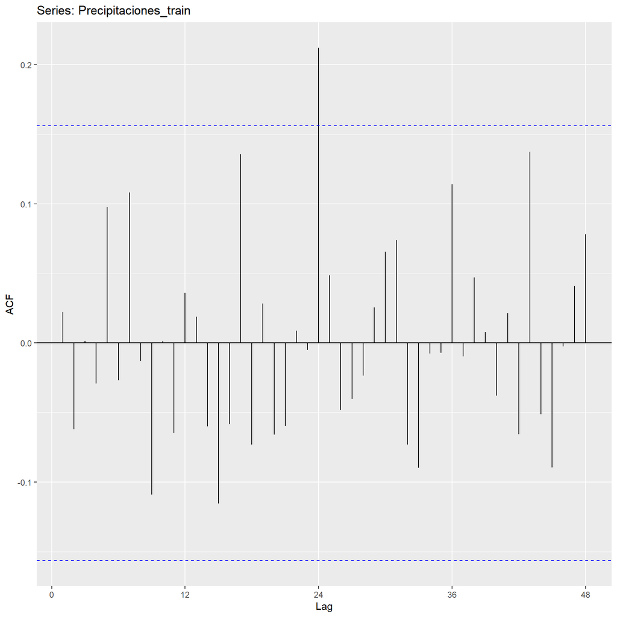

```r
#Representamos primero las autocorrelaciones simples hasta el retardo 48
ggAcf(Precipitaciones_train, lag=48)
```

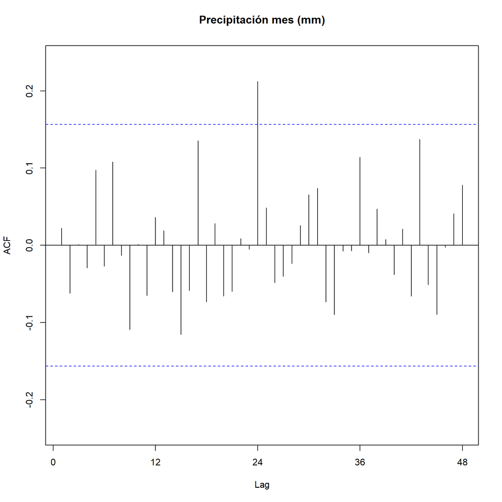

```r
corr <- Acf(Precipitaciones_train, lag=48)
```

```r
print(corr)
```

```
Autocorrelations of series 'Precipitaciones_train', by lag

     0      1      2      3      4      5      6      7      8      9
 1.000  0.022 -0.062  0.001 -0.029  0.098 -0.027  0.108 -0.013 -0.109
    10     11     12     13     14     15     16     17     18     19
 0.001 -0.065  0.036  0.019 -0.060 -0.115 -0.059  0.136 -0.073  0.028
    20     21     22     23     24     25     26     27     28     29
-0.066 -0.060  0.009 -0.005  0.212  0.049 -0.048 -0.040 -0.023  0.026
    30     31     32     33     34     35     36     37     38     39
 0.065  0.074 -0.073 -0.090 -0.008 -0.007  0.114 -0.010  0.047  0.008
    40     41     42     43     44     45     46     47     48
-0.038  0.021 -0.066  0.137 -0.051 -0.089 -0.002  0.041  0.078
```

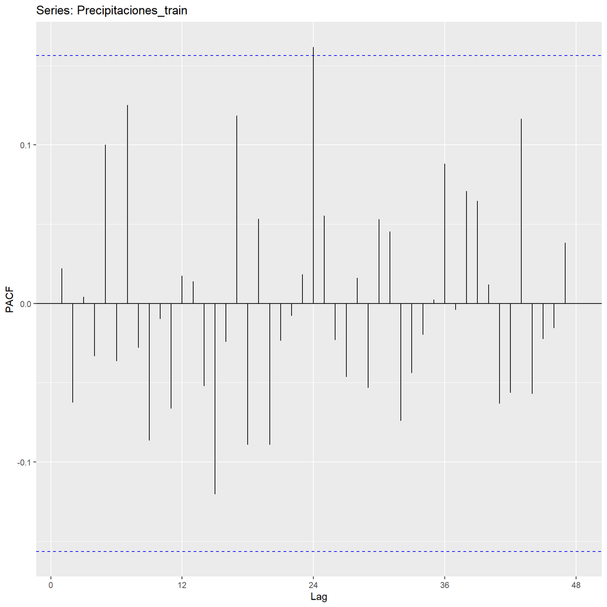

```r
#Representamos también las autocorrelaciones parciales hasta el retardo 48
ggPacf(Precipitaciones_train, lag=48)
```

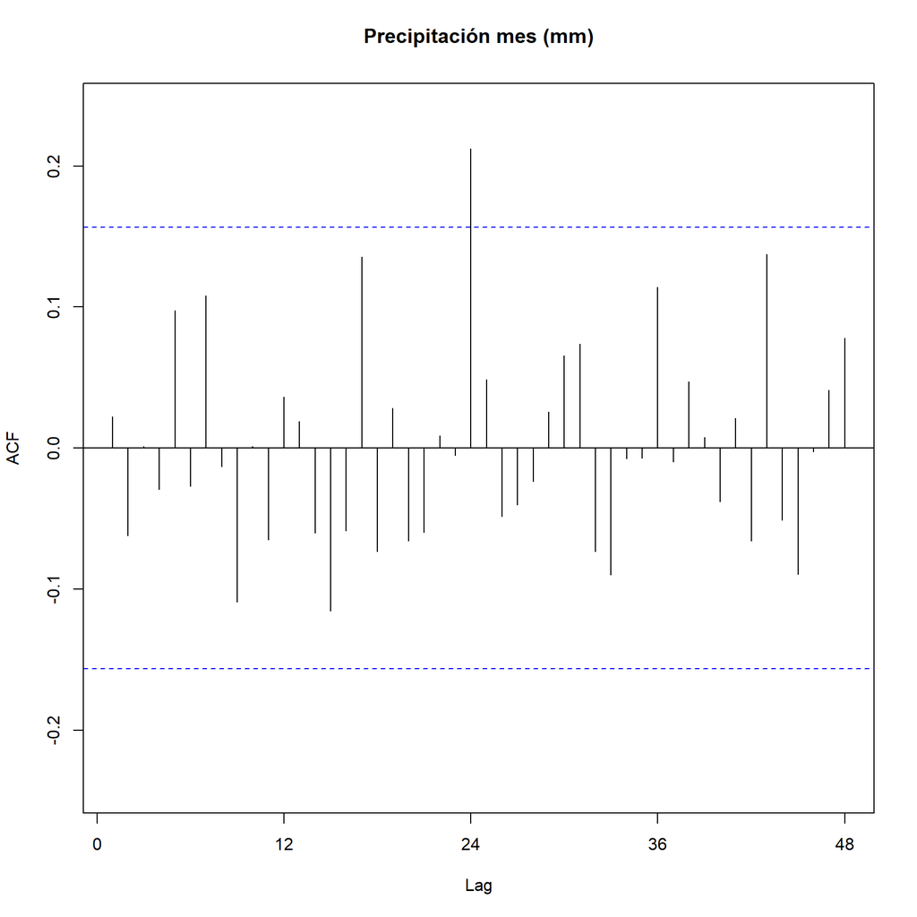

```r
corrP <- Acf(Precipitaciones_train, lag=48)
```

```r
print(corrP)
```

```
Autocorrelations of series 'Precipitaciones_train', by lag

     0      1      2      3      4      5      6      7      8      9
 1.000  0.022 -0.062  0.001 -0.029  0.098 -0.027  0.108 -0.013 -0.109
    10     11     12     13     14     15     16     17     18     19
 0.001 -0.065  0.036  0.019 -0.060 -0.115 -0.059  0.136 -0.073  0.028
    20     21     22     23     24     25     26     27     28     29
-0.066 -0.060  0.009 -0.005  0.212  0.049 -0.048 -0.040 -0.023  0.026
    30     31     32     33     34     35     36     37     38     39
 0.065  0.074 -0.073 -0.090 -0.008 -0.007  0.114 -0.010  0.047  0.008
    40     41     42     43     44     45     46     47     48
-0.038  0.021 -0.066  0.137 -0.051 -0.089 -0.002  0.041  0.078
```

Observamos lo mismo que en las autocorrelaciones simples, la que tiene un valor superior es la autocorrelación 24.

Al ser una serie claramente estacional, con la siguiente sintaxis visualizamos la gráfica de la serie y los autocorrelogramas generando una diferenciación de orden estacional

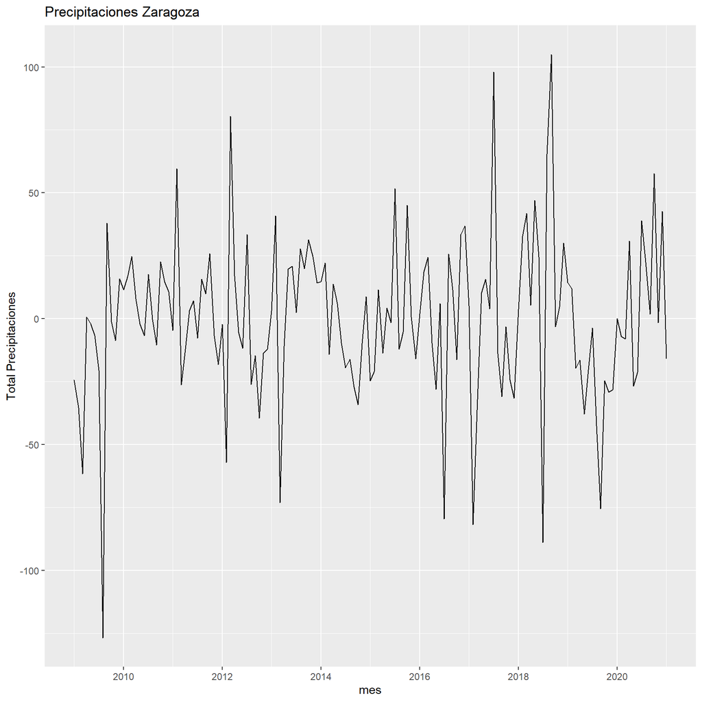

```r
autoplot(diff(Precipitaciones_train,12)) + ggtitle("Precipitaciones Zaragoza") +
  xlab("mes") + ylab("Total Precipitaciones")
```

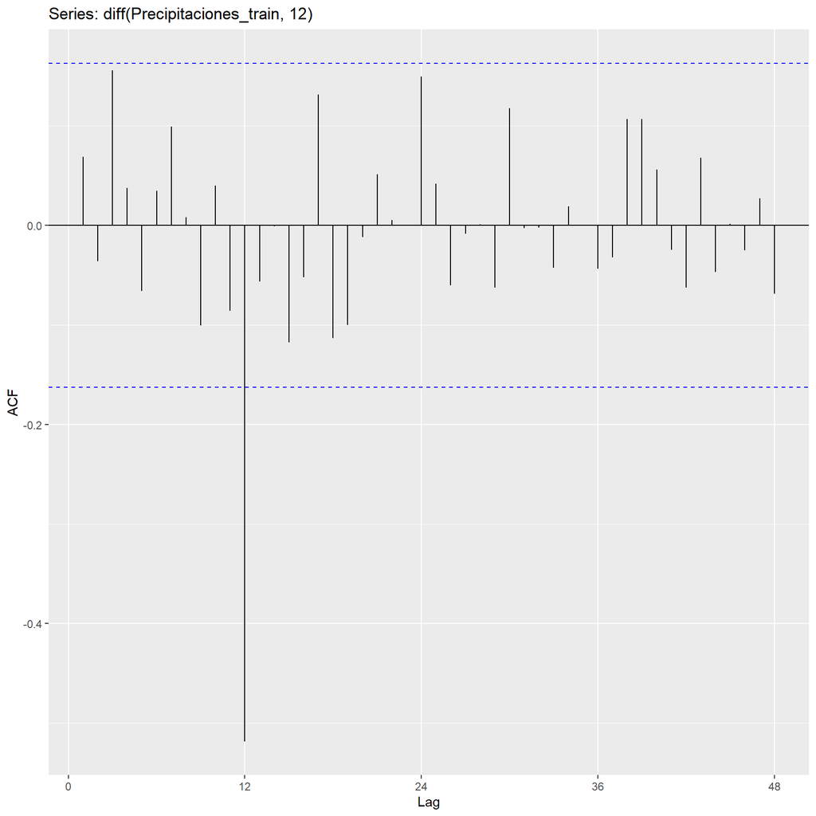

```r
#Volvemos a representamos las autocorrelaciones simples hasta el retardo 48 de la serie diferenciada
ggAcf(diff(Precipitaciones_train,12), lag=48)
```

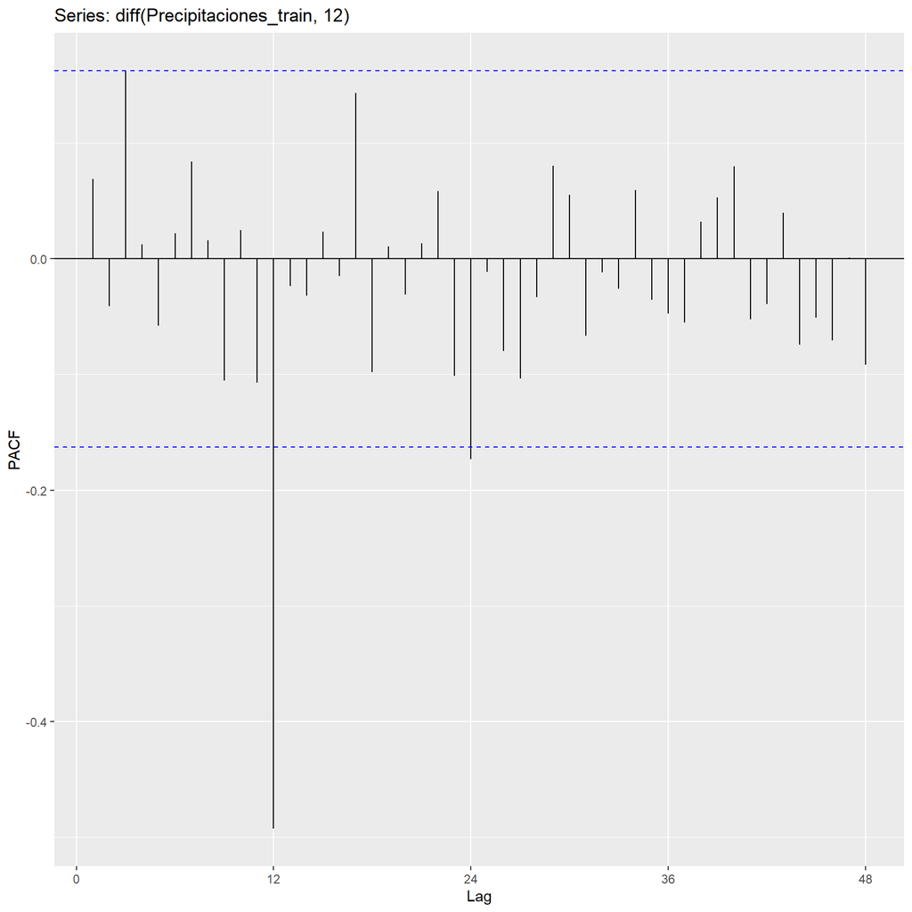

```r
#Probamos a repetir este proceso con la autocorrelación parcial
ggPacf(diff(Precipitaciones_train,12), lag=48)
```

Observamos que justamente es la autocorrelación 12 de la que depende la serie, aunque la autocorrelación de orden 3 también está justo en el límite. Ajustaremos el modelo ARIMA con estos datos obtenidos.

```r
#Realizamos la prueba de Dickey-Fuller para comprobar si nuestra serie es estacionaria otra vez
seriedif <- diff(Precipitaciones_train,12)
adf.test(seriedif)
```

```
    Augmented Dickey-Fuller Test

data:  seriedif
Dickey-Fuller = -4.392, Lag order = 5, p-value = 0.01
alternative hypothesis: stationary
```

```r
#el p-valor es <0,05 luego la serie es estacionaria.
```

Vamos a ajustar el modelo Arima con los resultados obtenidos en las gráficas anteriores. El modelo ARIMA que vamos a probar es (1,1,0)(0,1,1)[12]

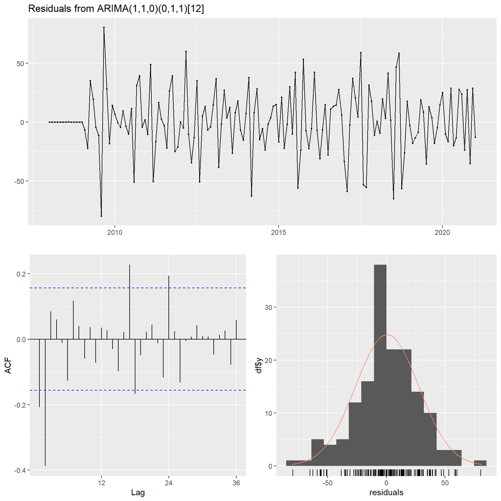

```
    Ljung-Box test

data:  Residuals from ARIMA(1,1,0)(0,1,1)[12]
Q* = 66.787, df = 22, p-value = 2.098e-06

Model df: 2.   Total lags used: 24
```

```r
fitPrecipitaciones1 <- Arima((Precipitaciones_train), c(1,1,0), seasonal=c(0,1,1))
checkresiduals(fitPrecipitaciones1)
```

Con el Ljung-Box test observamos que el pvalor es mucho menor de 0.05 luego rechazamos que los residuos estén incorrelados, lo que implica que el modelo no explica toda la dependencia de la serie

Vamos a probar ahora con la función autoArima

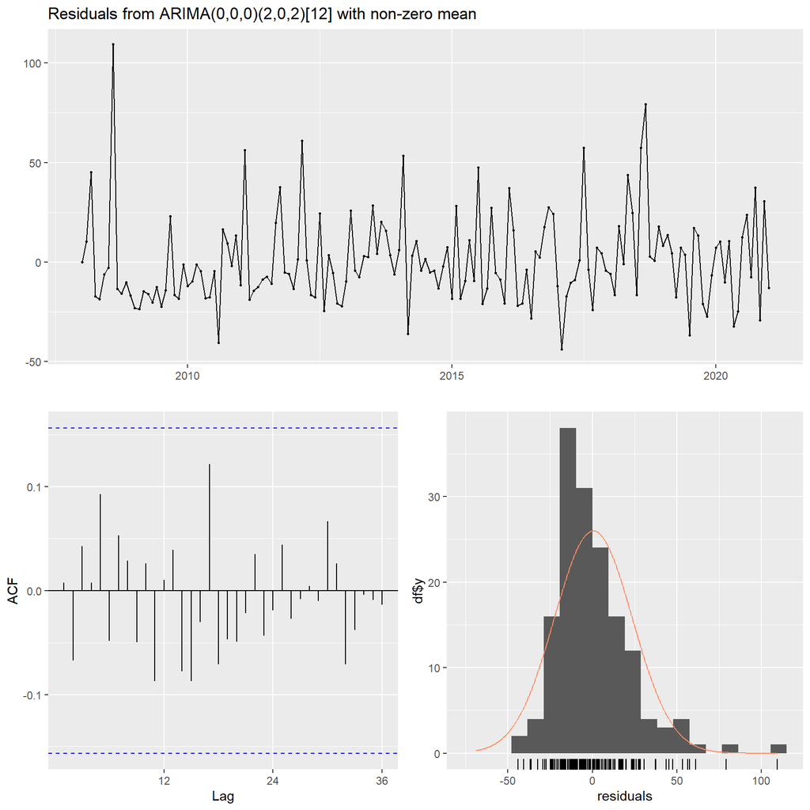

```
    Ljung-Box test

data:  Residuals from ARIMA(0,0,0)(2,0,2)[12] with non-zero mean
Q* = 13.233, df = 20, p-value = 0.8671

Model df: 4.   Total lags used: 24
```

```r
fitPrecipitaciones2 <- auto.arima(Precipitaciones_train)
checkresiduals(fitPrecipitaciones2)
```

Observamos que el p valor es mayor a 0.05 luego cogemos como bueno este modelo Arima (0,0,0)(2,0,2)[12], en este modelo Arima se acepta la hipótesis de que los residuos estén incorrelados.

# Calcular las predicciones y los intérvalos de confianza para las unidades de tiempo que se considere oportuno, dependiendo de la serie, siguientes al último valor observado

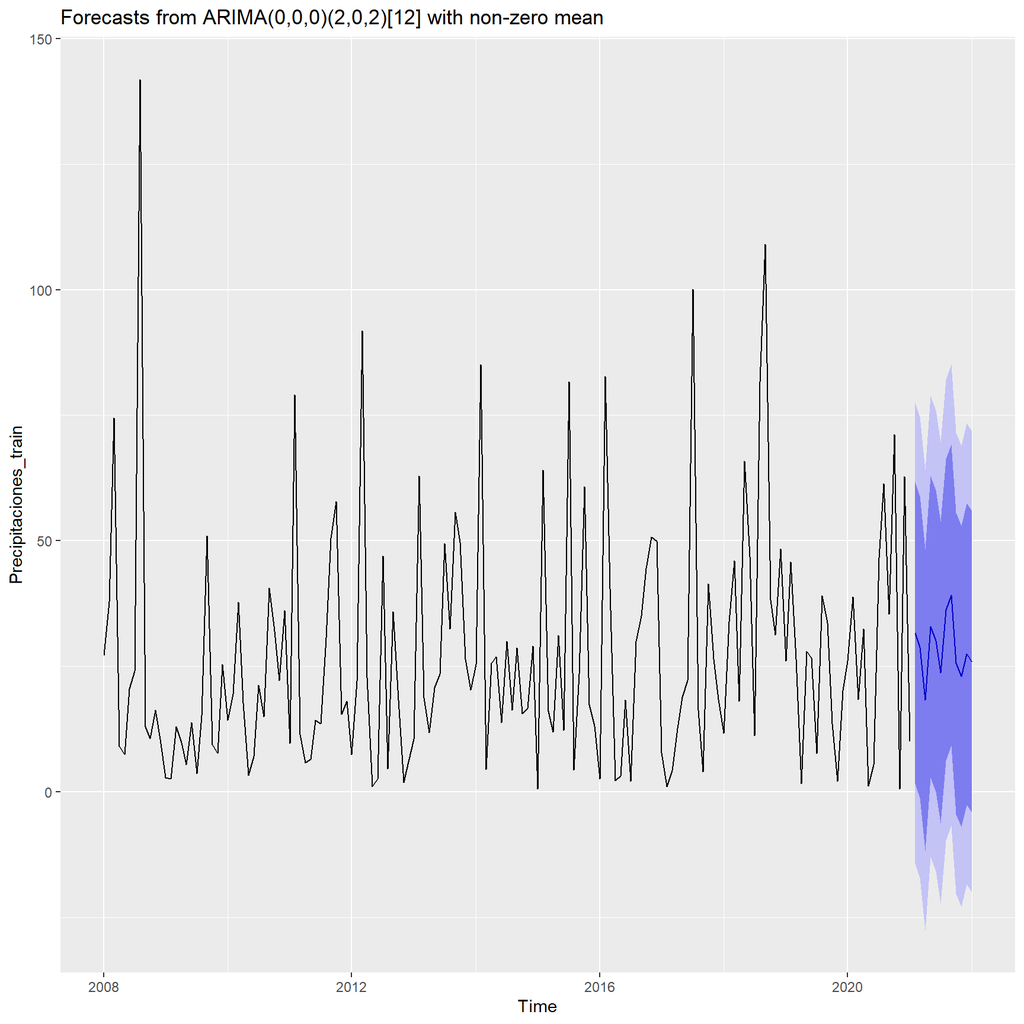

```r
#Representamos graficamente estas predicciones
autoplot(forecast(fitPrecipitaciones2, h=12))
```

```r
#Mostramos los valores de las predicciones
knitr::kable(forecast(fitPrecipitaciones2, h=12), digits = 4, caption = "Predicciones")
```

Table 4: Predicciones

|  | Point Forecast | Lo 80 | Hi 80 | Lo 95 | Hi 95 |
| --- | --- | --- | --- | --- | --- |
| Feb 2021 | 31.6452 | 1.6263 | 61.6642 | -14.2648 | 77.5553 |
| Mar 2021 | 28.8027 | -1.2163 | 58.8217 | -17.1074 | 74.7128 |
| Apr 2021 | 18.3031 | -11.7158 | 48.3221 | -27.6069 | 64.2132 |
| May 2021 | 32.8702 | 2.8512 | 62.8892 | -13.0399 | 78.7802 |
| Jun 2021 | 30.0433 | 0.0244 | 60.0623 | -15.8667 | 75.9534 |
| Jul 2021 | 23.7285 | -6.2905 | 53.7475 | -22.1816 | 69.6386 |
| Aug 2021 | 36.2254 | 6.2064 | 66.2443 | -9.6847 | 82.1354 |
| Sep 2021 | 39.1393 | 9.1203 | 69.1582 | -6.7708 | 85.0493 |
| Oct 2021 | 25.5556 | -4.4634 | 55.5746 | -20.3544 | 71.4657 |
| Nov 2021 | 23.0032 | -7.0158 | 53.0222 | -22.9069 | 68.9133 |
| Dec 2021 | 27.4294 | -2.5896 | 57.4484 | -18.4807 | 73.3395 |
| Jan 2022 | 25.8601 | -4.1589 | 55.8791 | -20.0500 | 71.7702 |

# Comparación de las predicciones obtenidas con cada uno de los métodos (suavizado y ARIMA) con los valores observados reservados previamente

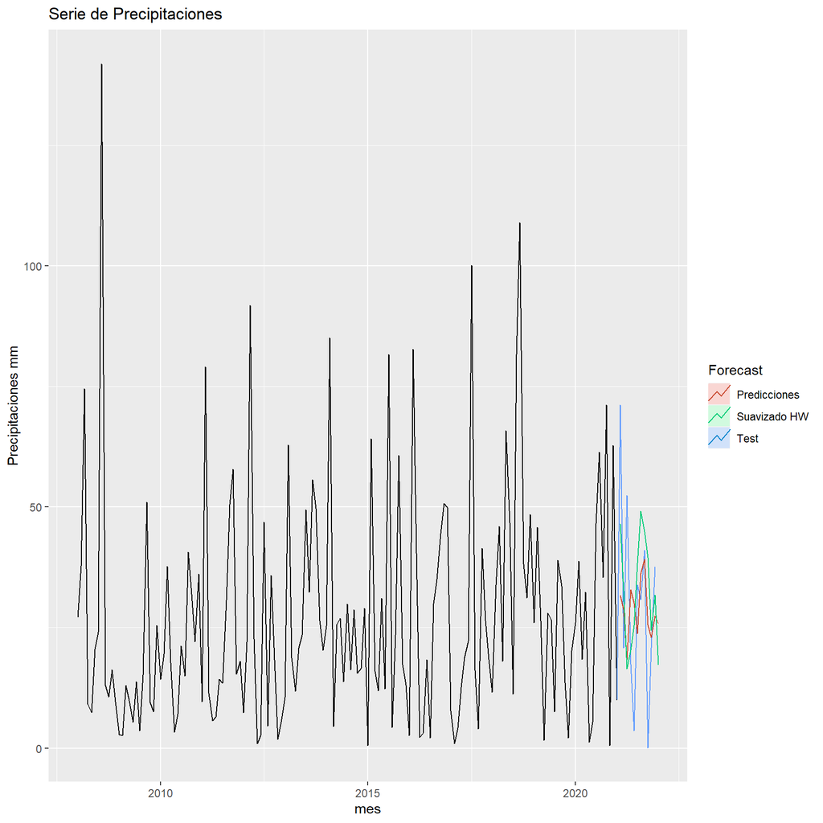

```r
#Representamos todas las series juntas para poder compararlas
autoplot(Precipitaciones) +
  autolayer(Precipitaciones_test, series="Test") +
  autolayer(forecast(fitPrecipitaciones2, h=12), series="Predicciones", PI=FALSE) +
  autolayer(Predicciones_shw, series = "Suavizado HW", PI=FALSE) + ylab("Precipitaciones mm") + xlab("mes") +
  ggtitle("Serie de Precipitaciones") + guides(colour = guide_legend(title = "Forecast"))
```

Realizamos un zoom para centrarnos en la zona de predicción

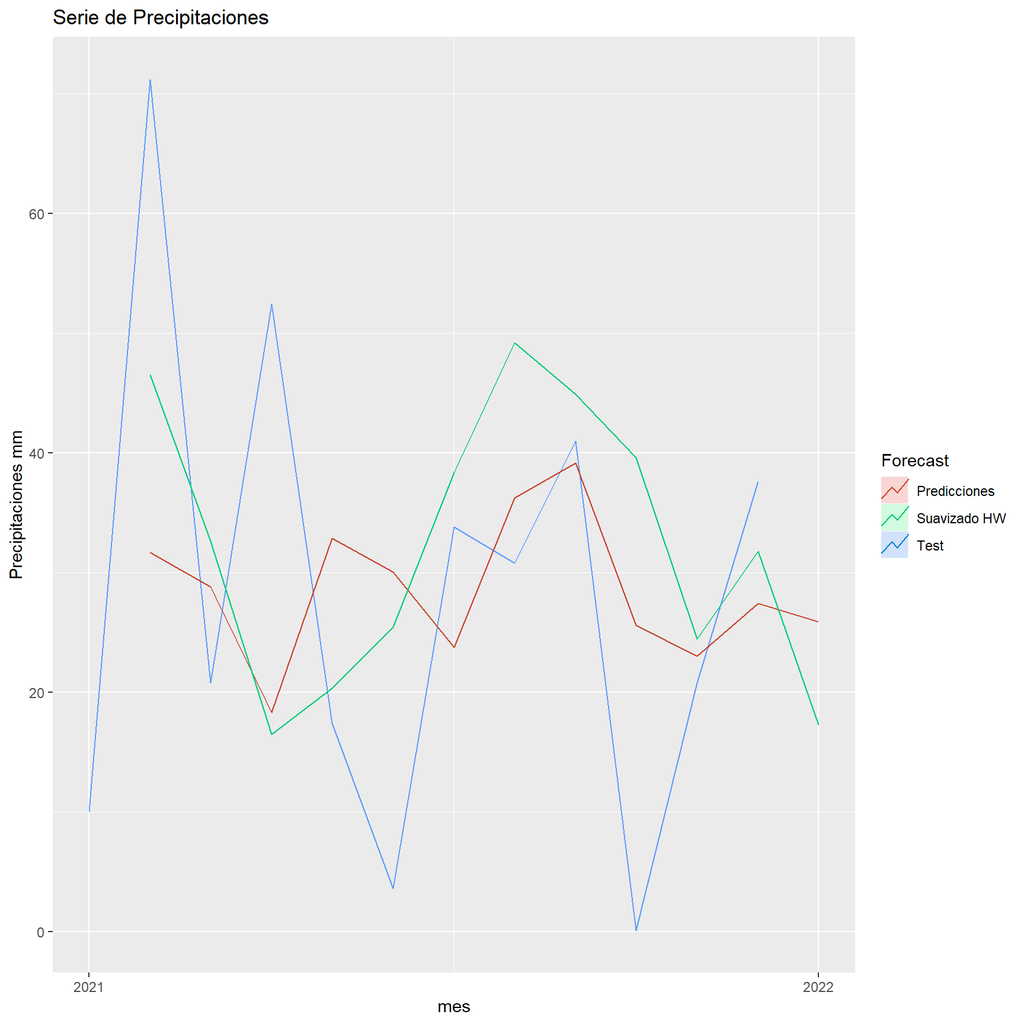

```r
autoplot(Precipitaciones_test, series="Test") +
  autolayer(forecast(fitPrecipitaciones2, h=12), series="Predicciones", PI=FALSE) +
  autolayer(Predicciones_shw, series = "Suavizado HW", PI=FALSE) + ylab("Precipitaciones mm") + xlab("mes") +
  ggtitle("Serie de Precipitaciones") + guides(colour = guide_legend(title = "Forecast"))
```

Observamos que las tres gráficas tienen unos valores similares siendo la predicción conseguida con el suavizado de HW más similar a los datos reales ya que respeta más los valores más altos y más bajos de la gráfica mientras que nuestra predicción generada con el modelo ARIMA nos genera una gráfica mucho más suavizada con valores más intermedios.